# Reproducible Research Assignment 1

Jason Baker

August 12, 2015

This assignment provides some analysis and reporting for a series of questions related to activity monitoring data. The data has been recorded over a two month period (October and November of 2012) and is recorded in 5 minute intervals.

The data includes

- steps : number of steps taken in a 5 minute interval (NA for no recording)
- date : date of the measurement in YYY-MM-DD
- interval : Identifier for the 5 minute interval in which measurement was taken.

The data has been provided in CSV format.

### Loading and preprocessing data

#### Load the data and print summary information

```r
#read data file and print summary
data01 <- read.csv("activity.csv", header=TRUE, sep=",", stringsAsFactors = FALSE)
summary(data01)
```

```
##      steps            date              interval
##  Min.   :  0.00   Length:17568       Min.   :   0.0
##  1st Qu.:  0.00   Class :character   1st Qu.: 588.8
##  Median :  0.00   Mode  :character   Median :1177.5
##  Mean   : 37.38                      Mean   :1177.5
##  3rd Qu.: 12.00                      3rd Qu.:1766.2
##  Max.   :806.00                      Max.   :2355.0
##  NA's   :2304
```

#### Create a clean data-set with no NA values

```r
#remove cases where data not recorded and add column with R Date object
data02 <- data01[!is.na(data01$steps),]
data02$dateobj <- as.Date(data02$date)

summary(data02)
```

```
##      steps            date              interval         dateobj
##  Min.   :  0.00   Length:15264       Min.   :   0.0   Min.   :2012-10-02
##  1st Qu.:  0.00   Class :character   1st Qu.: 588.8   1st Qu.:2012-10-16
##  Median :  0.00   Mode  :character   Median :1177.5   Median :2012-10-29
##  Mean   : 37.38                      Mean   :1177.5   Mean   :2012-10-30
##  3rd Qu.: 12.00                      3rd Qu.:1766.2   3rd Qu.:2012-11-16
##  Max.   :806.00                      Max.   :2355.0   Max.   :2012-11-29
```

### What is the mean total number of steps taken per day?

Total steps taken :

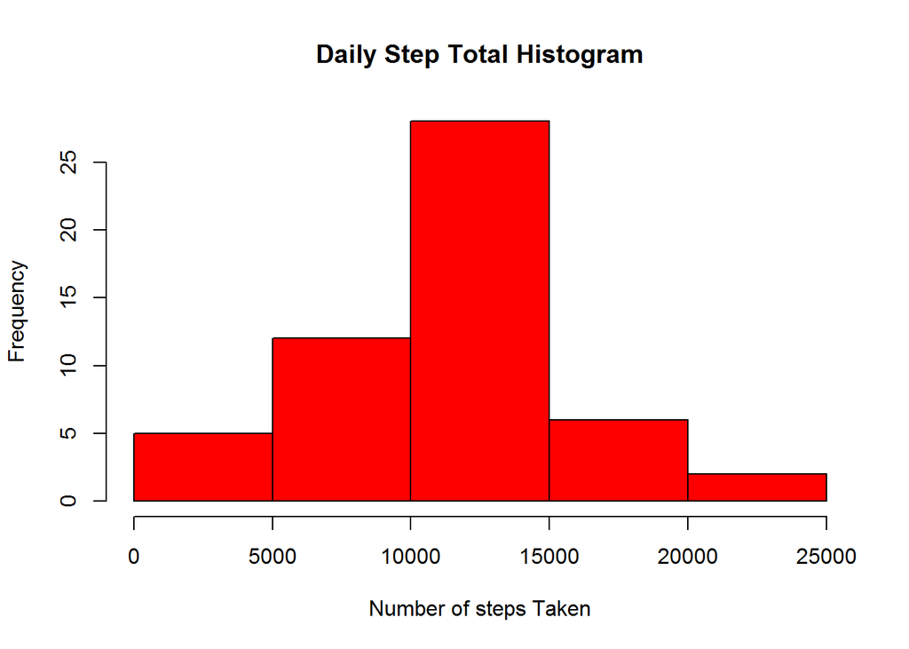

```r
# calculate total steps taken per day
totalSteps <- aggregate(steps~dateobj, data=data02, sum)
#present histogram of daily step sum
hist(totalSteps$steps,main="Daily Step Total Histogram",col = "red", xlab="Number of steps Taken")
```

```r
#determin mean and median of total steps per day
mean02 <- mean(totalSteps$steps)
median02 <- median(totalSteps$steps)
```

### What is the average daily activity pattern?

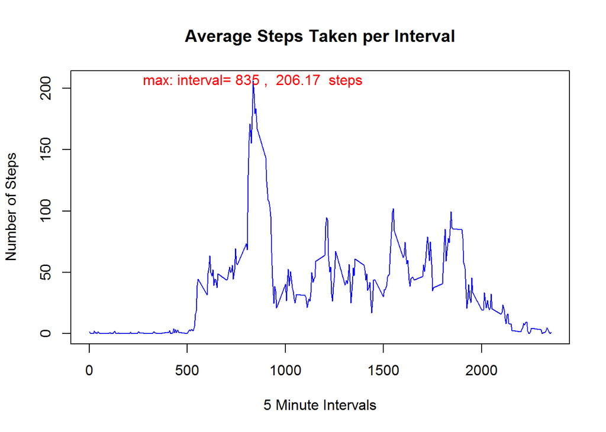

```r
# Sum the total steps for each interval
stepsByInterval <- aggregate(steps~interval, data=data02,mean)
plot(stepsByInterval$interval,stepsByInterval$steps,  type="n", main="Average Steps Taken per Interval", xlab="5 Minute Intervals" , ylab="Number of Steps")
points(stepsByInterval$interval,stepsByInterval$steps,  type="l", col="blue")

#Find the maximum and plot value
max <- stepsByInterval[stepsByInterval$steps==max(stepsByInterval$steps),]
text(max$interval,max$steps, col="red", labels=paste("max: interval=", max[1,1],", ",round(max[1,2], digits=2)," steps" ))
```

### Inputing missing values

```r
# determine the total number of missing data (steps=NA)
na_count <- sum(is.na(data01$steps))
```

Total number of NA rows found: 2304

A strategy for imputing values into the original table  
1. Find closest average available in stepsByInterval aggregate table (not all intervals are present) 2. Replace NA value with average 3. Run analytics again

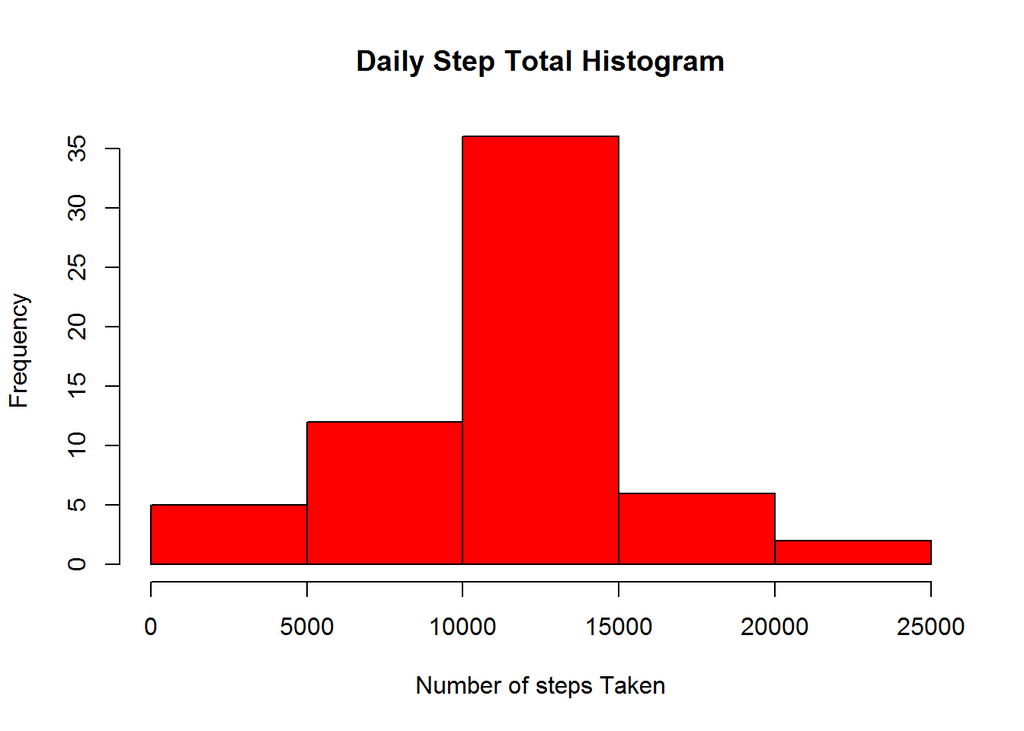

```r
# find rows with NA and copy original data for reference
data03 <- data01
has_na <- is.na(data03$steps)
for (i in 1:length(has_na)){
    if (has_na[i]){
        step <- stepsByInterval[stepsByInterval$interval==data03[i,3],]
        if(nrow(step) != 0){
            data03[i,1] <- step[1,2]
        }
        else{
            lowest <- 0
            highest <- 2355
            increment <- 5
            complete <- 1
            up <- step$interval
            down <- step$interval
            #search for the nearest average value
            while (complete != 1){
                up <- up + interval
                if (up <= highest){
                    temp <- stepsByInterval[stepsByInterval$interval==up,]
                    if (nrow(temp) > 0){
                        complete <- 0
                        data03[i,1] <- temp[1,2]
                    }
                }
                if (complete != 0){
                    down <- down - interval
                    if (down >= lowest){
                        temp <- stepsByInterval[stepsByInterval$interval==down,]
                        if (nrow(temp) > 0){
                            complete <- 0
                            data03[i,1] <- temp[1,2]
                        }
                    }
                }
                # set to zero as the worst case and complete
                if (up > highest && down < lowest){
                    if (complete > 0){
                        data03[i,1] <- 0
                        complete <- 0
                    }
                }
            }
        }
    }
}

# create the date object column
data03$dateobj <- as.Date(data03$date)

# determine mean, median and plot historgram
# calculate total steps taken per day
totalSteps03 <- aggregate(steps~dateobj, data=data03, sum)
#present histogram of daily step sum
hist(totalSteps03$steps,main="Daily Step Total Histogram",col = "red", xlab="Number of steps Taken")
```

```r
#determin mean and median of total steps per day
mean03 <- mean(totalSteps03$steps)
median03 <- median(totalSteps03$steps)
```

The mean value is 10766.2 (previous value was 10766.2) The median value is 10766.2 (previous value was 10765.0) Imputing missing values has made very little difference.

### Are there differences in activity patterns between weekdays and weekends?

```r
data03$weekday <- as.factor(sapply(data03$dateobj, function(x){day <- weekdays(x);if(day != "Saturday" && day != "Sunday"){return ("weekday")}else {return ("weekend")}}))

library(dplyr)
```

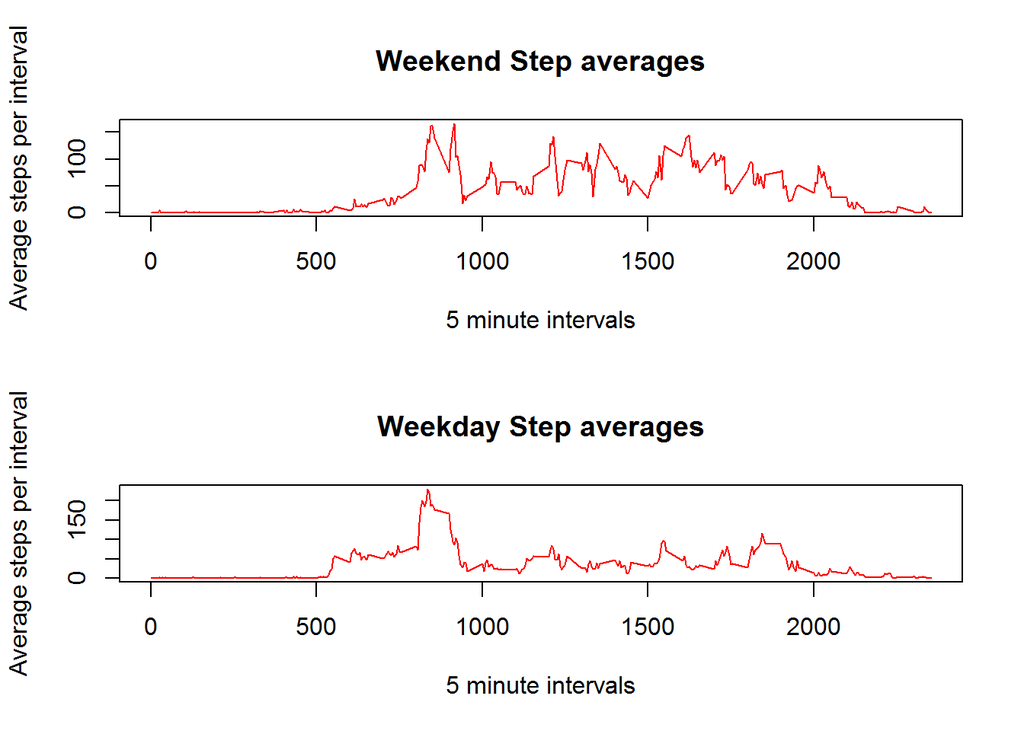

```r
groupedData03 <- group_by(data03, weekday,interval)
weekendData <- filter(groupedData03, weekday=="weekend")
weekendData_ag <- aggregate(steps~interval, data=weekendData, mean)
weekdayData <- filter(groupedData03, weekday=="weekday")
weekdayData_ag <- aggregate(steps~interval, data=weekdayData, mean)

# create the panel plot
par(mfrow=c(2,1))
plot(weekendData_ag$interval, weekendData_ag$steps, type="n", main="Weekend Step averages", xlab="5 minute intervals", ylab="Average steps per interval")
points(weekendData_ag$interval, weekendData_ag$steps, type="l", col="red")
plot(weekdayData_ag$interval, weekdayData_ag$steps, type="n", main="Weekday Step averages", xlab="5 minute intervals", ylab="Average steps per interval")
points(weekdayData_ag$interval, weekdayData_ag$steps, type="l", col="red")
```